# TP7 — Unsupervised Clustering

K-means, hierarchical clustering, and cluster validation - Breast cancer subtypes

Massimo Andreatta

2026-07-24

> **How to use this notebook.** You do **not** need any programming experience. Read each short explanation, then press the green *play* button (▶) at the top-right of each grey *code chunk* to run it. Look at the output, and answer the **Questions** in the green boxes (write your answers in plain text under each one). The goal is to *understand the data and the method*, not to memorise code.

> **Building on TP4–TP6.** This notebook assumes you have completed TP4–TP6, which introduced PCA using three different datasets and culminated in a full PCA analysis of a breast cancer gene-expression cohort (TP6). TP6 ended with a first taste of **unsupervised clustering** using k-means; here we slow down, cover clustering properly, add **hierarchical clustering**, and learn how to **validate** a clustering result rather than just eyeballing a plot.

# From PCA to clustering

## Two different questions

PCA and clustering are both **unsupervised** — neither uses the diagnosis or subtype labels. But they answer different questions:

- **PCA** asks: *what are the axes along which patients/tumours vary the most?* Its output is a set of continuous new coordinates (PC1, PC2, …).
- **Clustering** asks: *which points are similar enough to be grouped together?* Its output is a discrete label — cluster 1, cluster 2, … — for every point.

The two are often used together, exactly as we will do here: run PCA first to compress many genes into a handful of informative axes, then cluster the patients using those axes rather than the original noisy, high-dimensional data.

## Key vocabulary

| Term | Plain-language meaning |
| --- | --- |
| **Cluster** | A group of points considered similar to one another |
| **Distance / dissimilarity** | A number quantifying how different two points are — the input to every clustering method |
| **Centroid** | The “average” point of a cluster (used by k-means) |
| **Dendrogram** | A tree diagram showing how points are progressively merged in hierarchical clustering |
| **Linkage** | The rule used to decide how far apart two *clusters* are, based on the points inside them |
| **Within-cluster sum of squares (WSS)** | How spread out the points are within their assigned cluster — lower is tighter |
| **Silhouette width** | A score (from −1 to +1) for how well a point fits its own cluster compared with the next-closest cluster |
| **Adjusted Rand Index (ARI)** | A metric that compares two ways of grouping the same points. It scores **1** for a perfect match, **~0** for agreement no better than random chance, and negative values for worse-than-chance agreement… |

## A toy example: how k-means finds groups

Before working with a real dataset, let’s build intuition with two simple made-up measurements and three obviously separated groups of points.

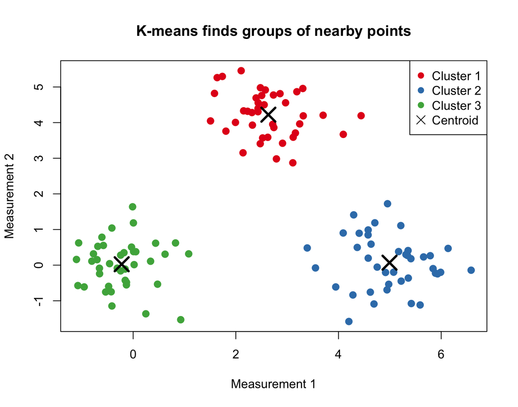

K-means starts from random guesses for the cluster centres, assigns every point to its nearest centre, recomputes the centres as the average of their assigned points, and repeats until nothing changes. The black crosses are the final **centroids** — the “centre of gravity” of each cluster.

> **Question 0.1.** In the toy plot above, the three groups are very obviously separated. How would k-means behave if the three blobs overlapped substantially? And what would happen to points that fall in the region where two blobs overlap?

> **Question 0.2.** K-means requires you to specify the number of clusters, *k*, in advance. In the toy example we told it `centers = 3`. What do you think would happen if we asked k-means for `centers = 2` on this same data? What about `centers = 6`?

# The dataset: breast cancer gene expression (recap)

We continue with the same **TCGA-BRCA** gene-expression dataset used in TP6: 522 tumours, 50 PAM50 genes, and a known PAM50 subtype label (LumA, LumB, Her2, Basal, NormalLike) for each tumour. As in TP6, we standardise the genes and run PCA — the code below reproduces that pipeline without repeating the explanations (see TP6 for the full walk-through).

```r
brca <- read.csv("../data/brca_pam50.csv", row.names = 1)
gene_cols <- colnames(brca)[7:56]

subtype_cols <- c(
  LumA       = "#1f77b4",
  LumB       = "#aec7e8",
  Her2       = "#ff7f0e",
  Basal      = "#d62728",
  NormalLike = "#7f7f7f"
)

X   <- scale(brca[, gene_cols])
pca <- prcomp(X, scale. = FALSE)
var_exp <- pca$sdev^2 / sum(pca$sdev^2) * 100

scores <- as.data.frame(pca$x)
scores$subtype <- factor(brca$pam50,
                         levels = c("LumA", "LumB", "Her2", "Basal", "NormalLike"))
col_pts <- subtype_cols[as.character(scores$subtype)]
```

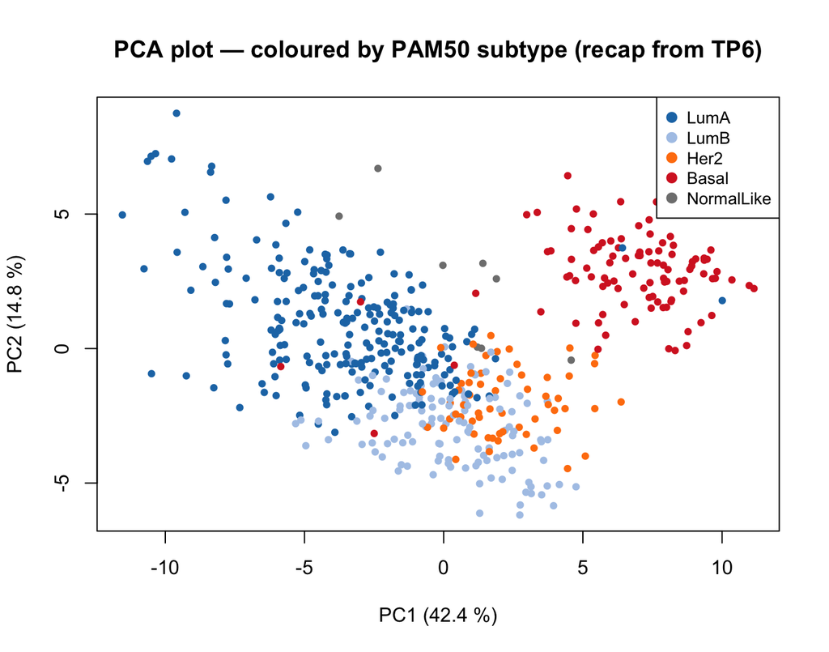

```r
plot(scores$PC1, scores$PC2,
     col  = col_pts, pch = 19, cex = 0.7,
     xlab = paste0("PC1 (", round(var_exp[1], 1), " %)"),
     ylab = paste0("PC2 (", round(var_exp[2], 1), " %)"),
     main = "PCA plot — coloured by PAM50 subtype (recap from TP6)")
legend("topright", legend = names(subtype_cols), col = subtype_cols,
       pch = 19, cex = 0.85, pt.cex = 1.1)
```

From here on, we will **not use the `subtype` colours to build the clusters** — clustering only sees the PCA coordinates. We use the known labels afterwards, purely to check whether the clusters we find agree with the known biology.

We cluster tumours using the first five PCs (which together capture most of the informative variance — see the scree plot in TP6) rather than the raw 50 genes: this reduces noise and speeds up computation.

```r
npc <- 5   # number of PCs used as clustering input
```

# 1 — K-means clustering

Can we **rediscover** the PAM50 subtypes **without** using the labels — only from the 50 gene expression values (summarised by their first 5 PCs)?

**K-means clustering** assigns each tumour to one of *k* groups so that tumours in the same group are as similar as possible to their group’s centroid — the same idea as the toy example above, now applied to real data.

## Choosing the number of clusters (elbow plot)

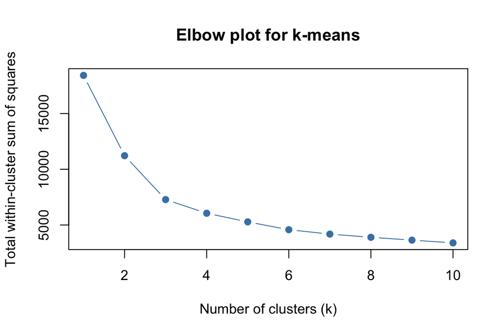

```r
set.seed(42)

wss <- sapply(1:10, function(k) {
  km <- kmeans(pca$x[, 1:npc], centers = k, nstart = 25)
  km$tot.withinss
})

plot(1:10, wss, type = "b", pch = 19, col = "steelblue",
     xlab = "Number of clusters (k)",
     ylab = "Total within-cluster sum of squares",
     main = "Elbow plot for k-means")
```

> **Question 1.1.** There are five known PAM50 subtypes (though Normal-like has only 8 samples). Does the elbow plot suggest *k* = 5 as a clear inflection point, or does the curve flatten earlier? What might this tell us about whether all five subtypes form truly distinct clusters in gene expression space?

## Clustering with k = 4

We choose *k* = 4 to match the four major clinical subtypes (LumA, LumB, Her2, Basal), setting aside the rare Normal-like category — and to allow a direct comparison with the hierarchical clustering below.

```r
set.seed(42)
cl_cols <- c("#e41a1c", "#377eb8", "#4daf4a", "#984ea3")

km <- kmeans(pca$x[, 1:npc], centers = 4, nstart = 25)
scores$cluster_km <- as.factor(km$cluster)
```

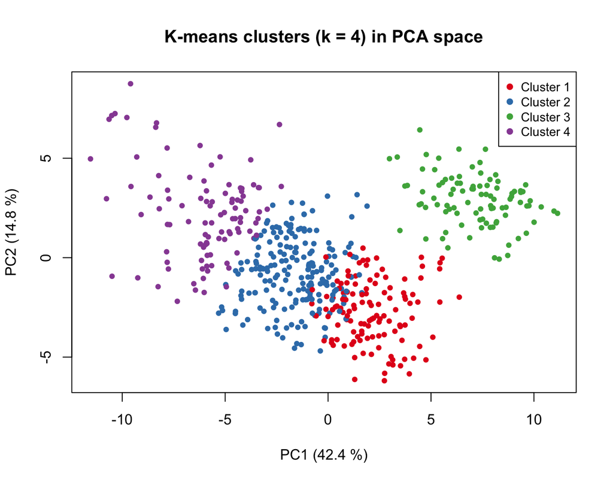

```r
plot(scores$PC1, scores$PC2,
     col = cl_cols[scores$cluster_km], pch = 19, cex = 0.7,
     xlab = paste0("PC1 (", round(var_exp[1], 1), " %)"),
     ylab = paste0("PC2 (", round(var_exp[2], 1), " %)"),
     main = "K-means clusters (k = 4) in PCA space")
legend("topright", legend = paste("Cluster", 1:4),
       col = cl_cols, pch = 19, cex = 0.85)
```

> **Question 1.2.** Are there clearly 4 clusters, or could one think of splitting the data into a different number of groups? How could one change the code to cluster the data with e.g. 2 clusters?

## How well do the k-means clusters match PAM50 subtypes?

We now have two criteria for splitting the data into groups: the known PAM50 subtype (stored in `scores$subtype`) and the unsupervised grouping produced by clustering (stored in `scores$cluster_km`). We can check if they agree:

```r
tab_km <- table(Cluster = scores$cluster_km, PAM50 = scores$subtype)
tab_km
```

```
##        PAM50
## Cluster LumA LumB Her2 Basal NormalLike
##       1    3   61   58     1          1
##       2  128   66    0     4          5
##       3    2    0    0    92          0
##       4   98    0    0     1          2
```

```r
round(prop.table(tab_km, margin = 1) * 100, 1)
```

```
##        PAM50
## Cluster LumA LumB Her2 Basal NormalLike
##       1  2.4 49.2 46.8   0.8        0.8
##       2 63.1 32.5  0.0   2.0        2.5
##       3  2.1  0.0  0.0  97.9        0.0
##       4 97.0  0.0  0.0   1.0        2.0
```

And in terms of proportions:

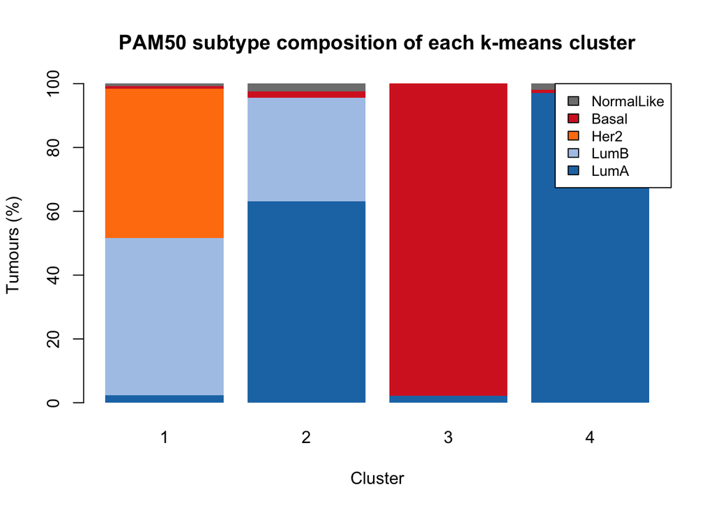

```r
pct_mat <- t(prop.table(tab_km, margin = 1)) * 100   # subtypes × clusters

barplot(pct_mat,
        col    = subtype_cols[rownames(pct_mat)],
        border = NA,
        legend.text = rownames(pct_mat),
        args.legend = list(x = "topright", cex = 0.85),
        ylab = "Tumours (%)", xlab = "Cluster",
        main = "PAM50 subtype composition of each k-means cluster")
```

> **Question 1.3.** Is any cluster dominated by a single PAM50 subtype? Which subtype is most cleanly captured by a single cluster, and which subtypes are most likely to be mixed together?

> **Question 1.4.** The clustering algorithm had no access to the PAM50 subtype labels — it worked only from gene expression values. Yet it partially recovers the clinical subtypes. What does this demonstrate about the information content of these 50 genes?

## Gene expression by cluster

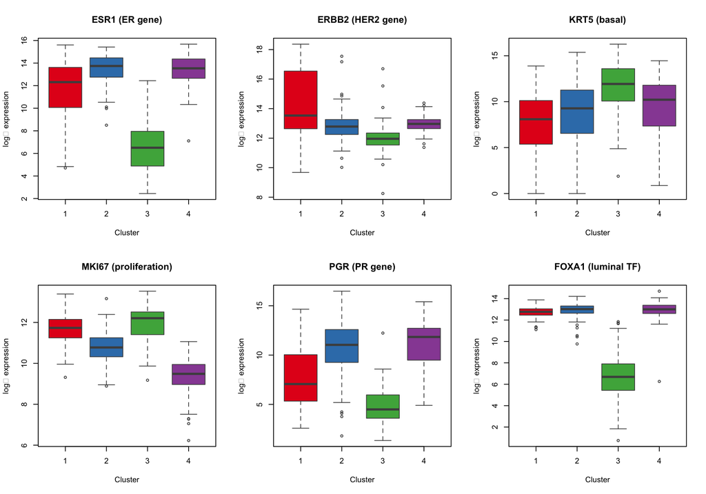

```r
highlight_genes <- c("ESR1", "ERBB2", "KRT5", "MKI67", "PGR", "FOXA1")
pretty <- c("ESR1 (ER gene)", "ERBB2 (HER2 gene)", "KRT5 (basal)",
            "MKI67 (proliferation)", "PGR (PR gene)", "FOXA1 (luminal TF)")

par(mfrow = c(2, 3))
for (i in seq_along(highlight_genes)) {
  boxplot(brca[[ highlight_genes[i] ]] ~ scores$cluster_km,
          col    = cl_cols, border = "grey30",
          main   = pretty[i],
          xlab   = "Cluster", ylab = "log₂ expression")
}
```

```r
par(mfrow = c(1, 1))
```

> **Question 1.5.** Look at the ESR1, PGR, and FOXA1 boxplots — these three genes are markers of hormone/luminal signalling. Which cluster(s) show the highest expression of all three, and does this match the cluster(s) most enriched for Luminal A tumours in the confusion table above? Now look at MKI67 (a proliferation marker) — is it highest in the same clusters, or in different ones? What does that tell you about how proliferative luminal tumours are likely to be?

> **Question 1.6.** One of the clusters is strongly associated with the basal cancer subtype. What is special about the gene expression patterns in this cluster? How does that relate to the fact that basal tumors are also often triple-negative breast cancers (TNBC)?

> **Question 1.7.** Which cluster has particularly high expression of the HER2 gene (ERBB2), and does that make sense in relation to which cancer types are enriched in this cluster?

> **Question 1.8.** Luminal A and Luminal B tumours are both ER-positive, yet they have different prognoses and treatment recommendations. If the unsupervised clustering tends to group them together, what does this suggest about how similar they are at the gene-expression level?

# 2 — Hierarchical clustering

## How it works

Hierarchical clustering does not require choosing *k* in advance. It starts with every point in its own cluster, then repeatedly **merges the two closest clusters** until only one giant cluster remains. The record of every merge is stored in a **dendrogram** — a tree you can “cut” at any height to obtain any number of clusters.

Two ingredients decide the result:

- **Distance metric** — how do we measure how far apart two individual tumours are? We use **Euclidean distance** on the first five PCs.
- **Linkage** — how do we measure the distance between two *clusters* (each containing several tumours), not just two points? We use **Ward’s method**, which merges clusters in the way that increases within-cluster variance the least — it tends to produce compact, similarly sized clusters.

```r
d  <- dist(pca$x[, 1:npc])
hc <- hclust(d, method = "ward.D2")
```

## The dendrogram

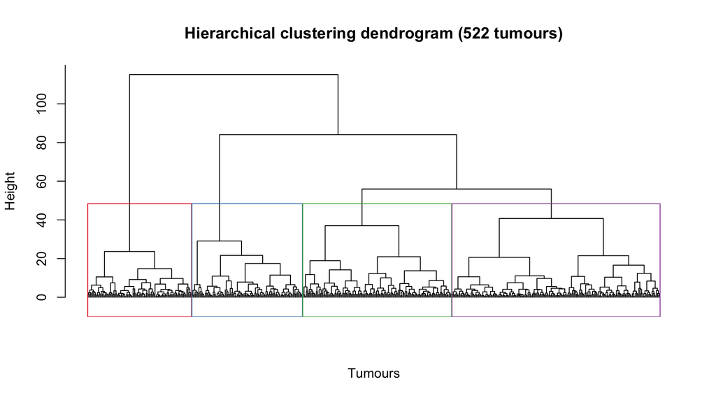

```r
plot(hc, labels = FALSE, hang = -1,
     main = "Hierarchical clustering dendrogram (522 tumours)",
     xlab = "Tumours", sub = "")
rect.hclust(hc, k = 4, border = cl_cols)
```

Each leaf at the bottom is one tumour (too many to label individually); the height of each merge shows how dissimilar the two merging groups were. The coloured boxes show where the tree is cut to produce **4 clusters** — the same number we used for k-means above, so the two methods can be compared fairly.

> **Question 2.1.** Looking at the dendrogram, do the four coloured boxes split off at similar heights, or does one box separate from the rest much earlier (at a much greater height) than the others? What would that tell you about how distinct that group is from the rest?

> **Question 2.2.** If you cut the dendrogram at a much lower height (close to 0), would you get more or fewer clusters than 4? What about cutting it at the very top, just below the root?

## Hierarchical clusters in PCA space

```r
scores$cluster_hc <- as.factor(cutree(hc, k = 4))
```

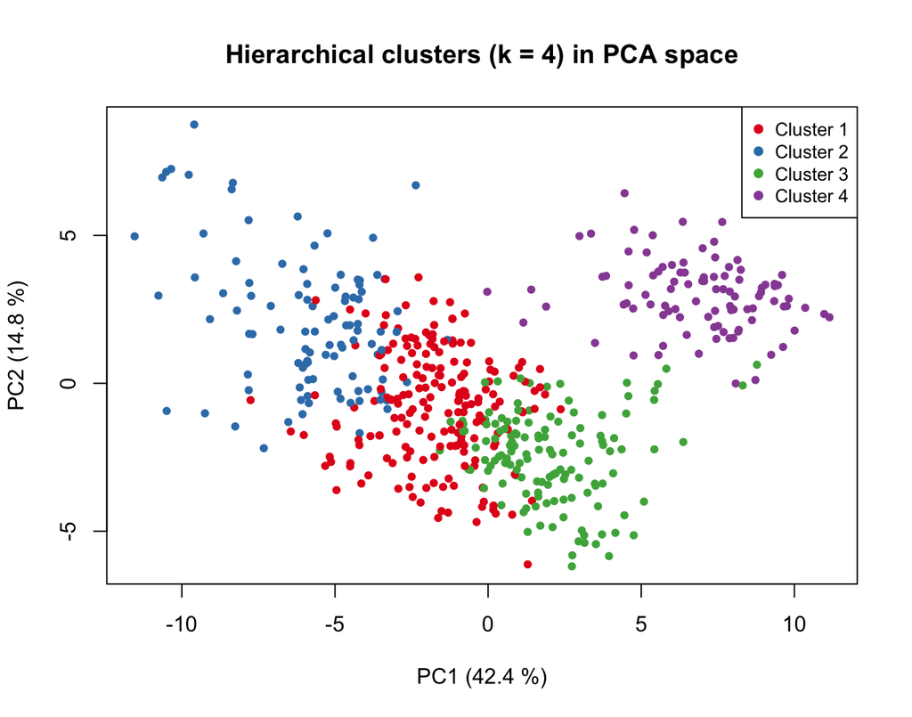

```r
plot(scores$PC1, scores$PC2,
     col  = cl_cols[scores$cluster_hc], pch = 19, cex = 0.7,
     xlab = paste0("PC1 (", round(var_exp[1], 1), " %)"),
     ylab = paste0("PC2 (", round(var_exp[2], 1), " %)"),
     main = "Hierarchical clusters (k = 4) in PCA space")
legend("topright", legend = paste("Cluster", 1:4), col = cl_cols,
       pch = 19, cex = 0.85)
```

## Do hierarchical clusters match the known PAM50 subtypes?

```r
tab_hc <- table(Cluster = scores$cluster_hc, PAM50 = scores$subtype)
tab_hc
```

```
##        PAM50
## Cluster LumA LumB Her2 Basal NormalLike
##       1  121   63    3     2          1
##       2   96    1    0     2          2
##       3   12   63   55     4          2
##       4    2    0    0    90          3
```

```r
round(prop.table(tab_hc, margin = 1) * 100, 1)
```

```
##        PAM50
## Cluster LumA LumB Her2 Basal NormalLike
##       1 63.7 33.2  1.6   1.1        0.5
##       2 95.0  1.0  0.0   2.0        2.0
##       3  8.8 46.3 40.4   2.9        1.5
##       4  2.1  0.0  0.0  94.7        3.2
```

> **Question 2.3.** Compare the hierarchical-clustering PCA plot with the PAM50-coloured PCA plot from the recap section. Does one hierarchical cluster correspond closely to a single PAM50 subtype? Which subtype is “easiest” for hierarchical clustering to isolate?

> **Question 2.4.** Ward’s linkage tends to produce clusters of similar size. Looking at the cluster sizes in the confusion table, does this assumption seem appropriate for this dataset — are the true PAM50 subtypes (see the bar chart in TP6, section 1) roughly equal in size, or very unequal? Could a “prefers equal-sized clusters” method be a poor fit here?

# 3 — Comparing the two clustering methods

K-means and hierarchical clustering start from very different logic (an iteratively updated set of centroids vs. a merging tree), but we ran both with the same *k* = 4 on the same 5-dimensional PCA input. How similar are their results?

```r
tab_compare <- table(`K-means` = scores$cluster_km, `Hierarchical` = scores$cluster_hc)
tab_compare
```

```
##        Hierarchical
## K-means   1   2   3   4
##       1  15   0 109   0
##       2 162  13  24   4
##       3   0   0   3  91
##       4  13  88   0   0
```

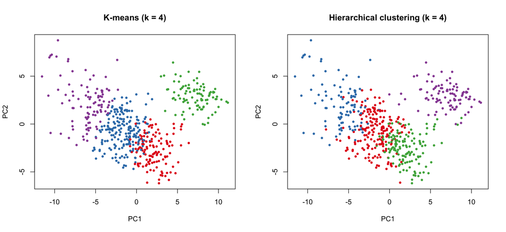

```r
par(mfrow = c(1, 2))

plot(scores$PC1, scores$PC2,
     col = cl_cols[scores$cluster_km], pch = 19, cex = 0.6,
     xlab = "PC1", ylab = "PC2", main = "K-means (k = 4)")

plot(scores$PC1, scores$PC2,
     col = cl_cols[scores$cluster_hc], pch = 19, cex = 0.6,
     xlab = "PC1", ylab = "PC2", main = "Hierarchical clustering (k = 4)")
```

```r
par(mfrow = c(1, 1))
```

> **Question 3.1.** Look at the cross-tabulation above. Is there roughly a **one-to-one correspondence** between k-means clusters and hierarchical clusters (each k-means cluster maps almost entirely onto one hierarchical cluster), or is the agreement weaker than that? Note that cluster *numbers* are arbitrary and may not match between methods — focus on whether entire *groups* of tumours agree, not on matching numeric labels.

> **Question 3.2.** Where the two methods *disagree*, which tumours do you think are involved — ones near the centre of a cluster, or ones near the boundary between two clusters? Why would boundary tumours be the ones most likely to be assigned differently by two different algorithms?

# 4 — How many clusters? Silhouette validation

The elbow plot in section 1 is useful but subjective — there is no single “correct” answer for where the elbow is. The **silhouette width** gives a more objective, per-point score.

## What silhouette width measures

For each point, the silhouette width compares:

- **a** = the average distance to other points in its *own* cluster (lower is better — the point fits well where it is)
- **b** = the average distance to points in the *nearest other* cluster (higher is better — the point is far from its nearest alternative)

The silhouette width is `(b - a) / max(a, b)`, ranging from **−1** (probably in the wrong cluster) to **+1** (very well matched to its cluster). Averaging this score across all points gives a single number to compare different values of *k*.

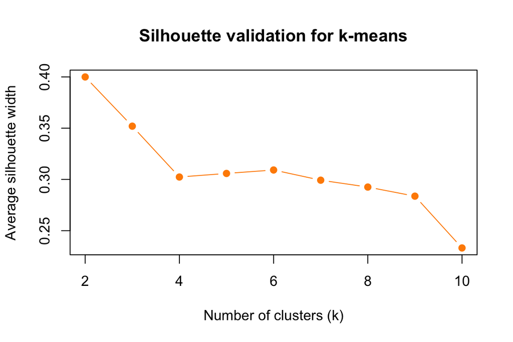

```r
library(cluster)

sil_width <- sapply(2:10, function(k) {
  cl <- kmeans(pca$x[, 1:npc], centers = k, nstart = 25)$cluster
  mean(silhouette(cl, d)[, "sil_width"])
})

plot(2:10, sil_width, type = "b", pch = 19, col = "darkorange",
     xlab = "Number of clusters (k)",
     ylab = "Average silhouette width",
     main = "Silhouette validation for k-means")
```

> **Question 4.1.** Which value of *k* has the highest average silhouette width? Is it the same value suggested by the elbow plot, or by the known number of PAM50 subtypes (5, or 4 if Normal-like is excluded)? If they disagree, which one would you trust more, and why?

## Silhouette plot for k = 4

We can also look at silhouette width **per tumour**, grouped by cluster, to see whether some clusters are much better defined than others.

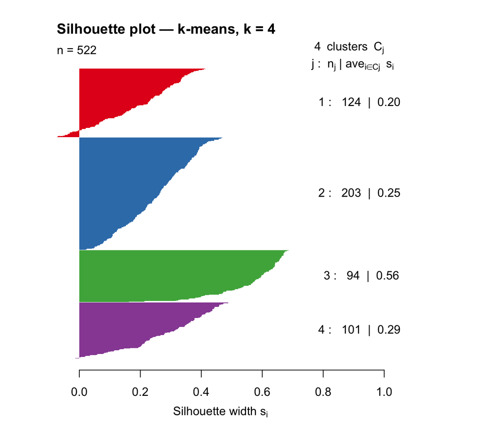

```r
sil_km <- silhouette(km$cluster, d)

par(mar = c(4, 4, 4, 8))
plot(sil_km, col = cl_cols, border = NA,
     main = "Silhouette plot — k-means, k = 4", cex.names = 0.7)
```

Each horizontal bar is one tumour; bars are grouped and sorted by cluster. Tumours with a **negative** silhouette width are, on average, closer to a *different* cluster than the one they were assigned to — a sign of a poorly-defined boundary or a genuinely intermediate tumour.

> **Question 4.2.** Which cluster has the highest average silhouette width (shown in the per-cluster label), and which has the lowest? Cross-reference with the PAM50 confusion table from section 1 — is the cluster with the *highest* silhouette width also the one most dominated by a single PAM50 subtype?

> **Question 4.3.** Are there any tumours with a negative silhouette width? Based on what you learned about Luminal A and Luminal B being biologically similar, would you expect tumours from these two subtypes to be over-represented among the poorly-clustered (low or negative silhouette) points?

## Internal vs. external validation: checking against known labels

Silhouette width (like the elbow plot) is an **internal** validity measure — it only looks at the geometry of the clusters themselves (how compact, how well-separated), with no idea whether the resulting groups mean anything biologically. Because we happen to know the true PAM50 subtype of every tumour, we can also compute an **external** validity measure: how well does each clustering solution agree with the known labels? In most real unsupervised analyses labels do not exist, so this check is a luxury — but it is a good way to see what internal measures can and cannot tell you.

The **Adjusted Rand Index (ARI)** compares two groupings of the same points. It scores **1** for a perfect match, **~0** for agreement no better than random chance, and negative values for worse-than-chance agreement.

```r
# Adjusted Rand Index: agreement between two clusterings of the same points
# (1 = perfect match, ~0 = no better than random)
adjusted_rand_index <- function(cl1, cl2) {
  tab     <- table(cl1, cl2)
  choose2 <- function(x) x * (x - 1) / 2
  n       <- sum(tab)

  index    <- sum(choose2(tab))
  expected <- sum(choose2(rowSums(tab))) * sum(choose2(colSums(tab))) / choose2(n)
  maxindex <- 0.5 * (sum(choose2(rowSums(tab))) + sum(choose2(colSums(tab))))

  (index - expected) / (maxindex - expected)
}
```

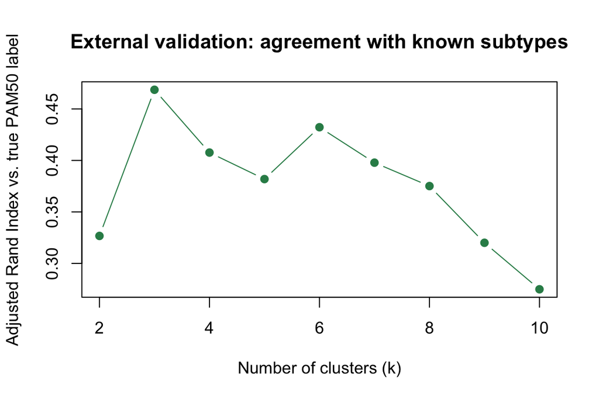

```r
set.seed(42)
ari_by_k <- sapply(2:10, function(k) {
  cl <- kmeans(pca$x[, 1:npc], centers = k, nstart = 25)$cluster
  adjusted_rand_index(cl, brca$pam50)
})

plot(2:10, ari_by_k, type = "b", pch = 19, col = "seagreen",
     xlab = "Number of clusters (k)",
     ylab = "Adjusted Rand Index vs. true PAM50 label",
     main = "External validation: agreement with known subtypes")
```

> **Question 4.4.** Compare the three curves you have now produced: the elbow plot (section 1), the silhouette-vs-*k* plot (above), and this ARI plot. Do they point to the same value of *k*, or to different ones? The elbow and silhouette curves are **internal** measures — they never see the PAM50 labels. ARI is **external** — it directly checks agreement against the labels. The silhouette width was highest at *k* = 2; can you think of a biological reason why the single largest split in these tumours might be a two-way one (hint: think about oestrogen-receptor status)? What does the fact that internal measures do not necessarily peak at the “clinically correct” number of clusters tell you about the limits of choosing *k* in a purely unsupervised way, with no external knowledge at all?

# 5 — Wrap-up